# Genetic ancestry principal components

## What genetic PCs capture

**Genetic ancestry** describes which populations a person’s genome descends from. It is a property of DNA, not a social label. Because populations that were separated for a long time drifted apart in allele frequencies, an individual’s genotypes at many thousands of common variants carry a record of that descent. In a cohort drawn from several continents the largest differences in allele frequency fall between continental groups, so the leading axes of genetic variation broadly separate African, European, East Asian, South Asian and American ancestries. Within one continental group, the same approach picks up finer regional structure; within Europe, for example, the first two PCs reproduce the map of the continent (Novembre et al. 2008). **Admixture** is the case where a person’s genome descends from more than one population, as it does for most African Americans, who carry both African and European ancestry in proportions that vary from person to person (Bryc et al. 2015).

**Principal component analysis** (PCA) summarises a table of many correlated variables with a few new variables, the principal components (PCs) (Jolliffe and Cadima 2016). Each PC is a weighted sum of the original variables, chosen so that the first PC captures as much of the variance in the data as possible, the second captures the most of what remains while being uncorrelated with the first, and so on. Applied to a genotype matrix (individuals × variants, coded 0/1/2 copies of one allele), each individual gets a score on each PC. Two individuals with similar allele frequencies across the genome get similar scores, so they sit close together when the scores are plotted; individuals from different populations sit far apart, and admixed individuals fall between the groups their ancestry comes from, roughly in proportion to how much of each they carry. The first few PCs of genome-wide genotypes therefore summarise genetic ancestry in a handful of continuous numbers (Patterson et al. 2006). Adjusting for those components is the standard correction for population stratification in genetic association studies (Price et al. 2006; Patterson et al. 2006), and it carries over to EWAS. DNA methylation differs with ancestry too. Barfield et al. found widespread associations between methylation and race in 388 individuals and showed that, left unadjusted, this population structure can confound a methylation study (Barfield et al. 2014). Part of the reason is genetic: sequence variants near a CpG can shift its methylation, and allele frequencies differ between populations. Chapter 03’s masks do not deal with this. They remove probes whose *measurement* a SNP can corrupt, but a CpG whose methylation genuinely differs with ancestry passes every mask. If ancestry is also related to the exposure, it is a confounder, and even if it is not, it is structured variation the model can explain.

From the next chapter on, every model in this tutorial carries three genetic ancestry principal components (PCs) as covariates: in ComBat and surrogate variable analysis in chapter 05, in the EWAS design in chapter 06, and in the pipeline’s phenotype file in chapter 07. They are added to account for underlying population substructure: if methylation at a CpG differs with ancestry, and ancestry is also unevenly distributed between cases and controls, the CpG would look associated with the exposure when it is not. Carrying the PCs as covariates lets the model attribute that variation to ancestry rather than to the exposure. This short chapter explains what the PCs are, how they relate to self-reported race, and what to do when a dataset does not include them.

**NoteWhat this chapter needs**

Everything up to the EPISTRUCTURE example needs only `data/sample_sheet.csv`, which is in the repository; the three PCs are its last three columns, `pc1`, `pc2` and `pc3`. The EPISTRUCTURE example at the end also reads `data/02_funnorm_grs.rds`, written at the end of normalization, and `data/04_cellcounts.rds`, written by cell composition and committed to the repository.

```r
library(ggplot2)   # the scatter plot below
library(dplyr)     # filter() and left_join() for the sample sheet

ss   <- read.csv("data/sample_sheet.csv", stringsAsFactors = FALSE)
gpcs <- c("pc1", "pc2", "pc3")

# The 86 samples an association model can use: PTSD status, sex, age and all three
# PCs recorded. These are the same 86 samples chapter 05 onwards models; one of the
# 96 arrays has no PCs, and nine have no PTSD status.
pcs <- ss %>%
  filter(!is.na(ptsd), ptsd != "",
         !is.na(sex), !is.na(age),
         !is.na(pc1), !is.na(pc2), !is.na(pc3))
cat("samples with PCs:", sum(complete.cases(ss[, gpcs])), "of", nrow(ss),
    "| modeled samples:", nrow(pcs), "\n")
```

```
samples with PCs: 95 of 96 | modeled samples: 86
```

## Genetic PCs and self-reported race

Genetic PCs and self-reported race are different kinds of variable, and neither replaces the other. Race is a social category: the labels available, and which one a person is assigned or chooses, are set by the society they live in, not by their genome (National Academies of Sciences, Engineering, and Medicine 2023; Borrell et al. 2021). Genetic ancestry is a property of the genome, and the PCs describe it continuously (Lewis et al. 2022). The two are correlated in many cohorts, because people who share a racial label often share ancestry, but the correlation is not fixed, and it is often weak within a group: individuals recorded under one label can differ widely in ancestry, most obviously in admixed populations (Bryc et al. 2015). Race also carries information genetic PCs cannot: it is the variable through which the effects of systemic racism, socioeconomic position, and other social and environmental exposures act on health, and those exposures shape DNA methylation (Borrell et al. 2021). So a race covariate and genetic PCs adjust for different things, and the 2023 National Academies report on population descriptors recommends using genetic ancestry, not race, when the aim is to account for genetic population structure, and naming which descriptor was used and why (National Academies of Sciences, Engineering, and Medicine 2023).

For this tutorial’s purpose, adjusting for population substructure, genetic PCs are the appropriate variable: they measure the structure directly and continuously. Whether to also include self-reported race depends on the question. In a study of a socially patterned exposure, race may be an important covariate or even the exposure itself; in a study of a molecular trait, genetic PCs alone may be the better-specified choice. The Grady cohort also shows why race cannot stand in for the PCs here: almost every modeled sample carries the same label, so a categorical race variable doesn’t provide meaningful differentiation for a statistical model, while the genetic PCs still vary from sample to sample:

```r
table(race = ifelse(is.na(pcs$race) | pcs$race == "", "not recorded", pcs$race))
```

```
race
          AA not recorded        Other
          81            1            4
```

```r
# Their spread within the modeled set: continuous, and centred near zero because
# they were computed on the whole cohort.
round(sapply(pcs[, gpcs], summary), 4)
```

```
            pc1     pc2     pc3
Min.    -0.0114 -0.0401 -0.0334
1st Qu. -0.0062 -0.0075 -0.0073
Median  -0.0028 -0.0003  0.0003
Mean    -0.0005 -0.0018  0.0020
3rd Qu.  0.0013  0.0051  0.0112
Max.     0.0610  0.0276  0.0353
```

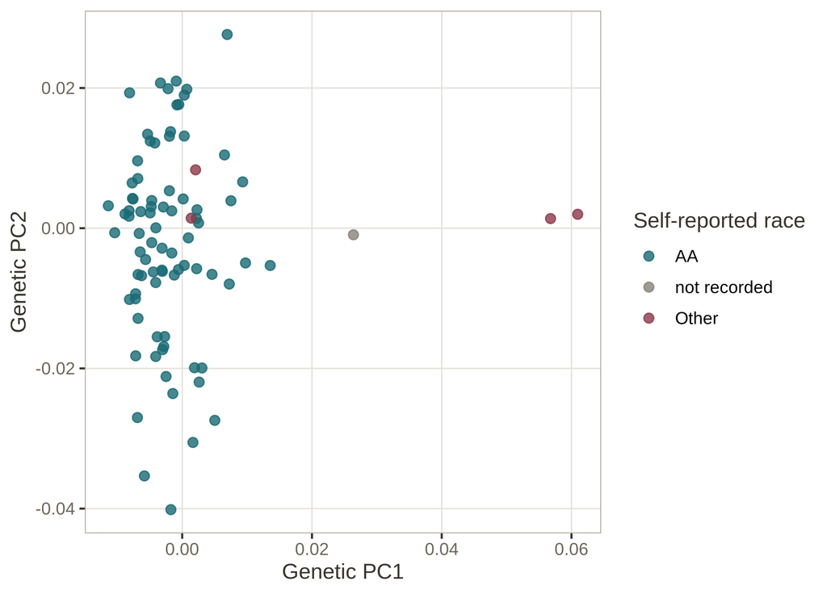

The first two genetic ancestry PCs for the 86 modeled samples, coloured by self-reported race. Samples recorded with the same race label still spread along both components: this is the genetic variation a categorical race variable cannot represent, and the reason the PCs are used to adjust for population substructure.

```r
ggplot(pcs, aes(pc1, pc2, colour = ifelse(is.na(race) | race == "", "not recorded", race))) +
  geom_point(size = 2.2, alpha = 0.8) +
  scale_colour_manual(values = c(AA = "#1A6B75", Other = "#8C3A4A",
                                 `not recorded` = "#8A8279"),
                      name = "Self-reported race") +
  labs(x = "Genetic PC1", y = "Genetic PC2")
```

The heatmap in §2 of Batch effects includes the three components, so you can see how much of the methylation variance they account for before any model is fit.

## How many components

How many components a cohort needs depends on how structured it is. The usual way to decide is a scree plot: plot the variance each component explains against its rank and keep the components before the curve flattens, the “elbow” (Cattell 1966). EIGENSOFT’s `smartpca` also tests each component formally against a Tracy–Widom distribution (Patterson et al. 2006). Both need the full set of eigenvalues, which a deposit that ships only the first three PCs, as Grady’s does, cannot give you. Three is a common choice, and it is what the PGC-PTSD meta-analysis used for genotyped cohorts (Katrinli et al. 2024). In practice, most PCs beyond the first two or three within a continental group have little association with methylation and adjusting for them mainly costs degrees of freedom.

**TipIf your GEO deposit has no genetic PCs**

Most GEO methylation deposits do not include genetic PCs, so you will often have to make your own. In order of preference:

1. **Compute them from genotypes.** If genotype data exist for the same individuals, run a PCA on them. For a public methylation deposit this usually means the genotypes are under controlled access (for example on dbGaP), which requires an approved data access request from an institutional signing official, so it is rarely an option a student can arrange alone; ask whether your PI already has access. Remove rare variants and prune SNPs in linkage disequilibrium first, so that the components describe genome-wide ancestry rather than a few long haplotypes. PLINK 2 (Chang et al. 2015) and EIGENSOFT’s `smartpca` (Patterson et al. 2006; Price et al. 2006) are the standard tools:

   ```
   Generic example, do not run
   ```

   ```bash
   # `mydata` is a placeholder for a PLINK fileset (.bed/.bim/.fam) of your cohort.
   plink2 --bfile mydata --autosome --maf 0.05 \
          --indep-pairwise 200 50 0.2 --out pruned
   plink2 --bfile mydata --extract pruned.prune.in --pca 10 --out mydata_pcs
   # mydata_pcs.eigenvec: one row per individual, PC1-PC10 as columns
   ```

2. **Estimate ancestry from the methylation data.** Without genotypes, PCs can be computed from the methylation array itself. Barfield et al. showed that PCs built from CpGs chosen because they proxy nearby SNPs adjust for population stratification nearly as well as genotype PCs (Barfield et al. 2014). EPISTRUCTURE, part of the GLINT toolset, implements a related approach (Rahmani, Shenhav, et al. 2017; Rahmani, Yedidim, et al. 2017); the example below runs it on this cohort. The PGC-PTSD meta-analysis used Barfield’s method for its cohorts without genotypes and kept PCs 2 and 3, the components most correlated with self-reported ancestry (Katrinli et al. 2024). Because methylation-based components can also pick up cell composition or batch, check what they correlate with before you use them. Comparing them with self-reported race and with chapter 04’s cell proportions is our suggestion for a minimum check.
3. **Fall back on self-reported race or ethnicity.** If neither is possible, a categorical self-reported race or ethnicity covariate captures some of the population structure where the labels and ancestry are correlated, but it is a different kind of variable (above): it cannot represent admixture, and in a cohort where most samples share one label it adjusts for very little. Report it as a limitation and say which descriptor you used.

## Worked example: EPISTRUCTURE on the Grady data

Because Grady deposits genetic PCs, it lets us check how well a methylation-only method recovers them. EPISTRUCTURE (Rahmani, Shenhav, et al. 2017) works from a fixed list of 4,913 CpGs whose methylation was found to be strongly explained by nearby SNPs. It removes the effect of cell composition from those sites and takes principal components of what is left. GLINT, the toolset that implements it, is written for Python 2.7 (Rahmani, Yedidim, et al. 2017), so the steps are written out in R below. Run on this dataset, GLINT’s own `--epi` gives the same three components as this code: they correlate at r = −1 (the sign of a PC is arbitrary) and differ in scale only because scikit-learn standardizes with *n* rather than *n* − 1.

Two things about the input matter. First, the reference CpGs are exactly the kind of SNP-influenced sites probe filtering removes, so EPISTRUCTURE has to run on the normalized but **unfiltered** object; GLINT’s documentation makes the same recommendation. Second, the list was selected in European individuals, and this cohort is mostly African American, so how well it works here is a real question rather than a foregone conclusion.

```r
library(minfi)   # getBeta()

# GLINT's reference list, read from the GLINT repository at a fixed commit so it
# keeps returning this exact file.
ref <- readLines(paste0("https://raw.githubusercontent.com/cozygene/glint/",
                        "31a138ce380faeaf0e698733e781771df33374fe/",
                        "parsers/assets/epistructure_reference_sites.txt"))

# Normalized, unfiltered beta values for the reference sites that are on the EPIC
# array (the list was built on the 450K array, so a few are missing).
grs  <- readRDS("data/02_funnorm_grs.rds")
beta <- getBeta(grs[rownames(grs) %in% ref, ])
rm(grs)   # 1.25 GB; only the reference sites are needed from here on
cat("reference CpGs:", length(ref), "| on this array:", nrow(beta), "\n")
```

```
reference CpGs: 4913 | on this array: 4611
```

```r
# Covariates to remove before the PCA, in the same sample order as `beta`.
cells <- readRDS("data/04_cellcounts.rds")[colnames(beta), ]
sheet <- left_join(data.frame(sample_id = colnames(beta)), ss, by = "sample_id")

# EPISTRUCTURE: regress each reference site on the covariates, keep the residuals,
# standardize each site, and take principal components across samples.
epistructure <- function(beta, covariates, n_pcs = 3) {
  res <- t(lm.fit(covariates, t(beta))$residuals)
  prcomp(t(res), center = TRUE, scale. = TRUE)$x[, seq_len(n_pcs)]
}

# GLINT's documented usage regresses out cell composition only. On these arrays the
# components that gives also track the chip each sample was run on, so the version
# used below also removes sex and chip.
epi_cells <- epistructure(beta, cbind(1, cells))
epi       <- epistructure(beta, model.matrix(~ cells + sex + factor(slide), sheet))

# How much each version's first component tracks chip, and how closely it follows
# the deposited pc1 (95 samples; one has no deposited PCs).
has_pcs <- complete.cases(sheet[, gpcs])
chip_r2 <- function(e) summary(lm(e[, 1] ~ factor(sheet$slide)))$r.squared
data.frame(covariates_removed = c("cell types", "cell types, sex, chip"),
           chip_R2_of_EPI1    = round(c(chip_r2(epi_cells), chip_r2(epi)), 2),
           abs_r_with_pc1     = round(abs(c(cor(epi_cells[has_pcs, 1], sheet$pc1[has_pcs]),
                                            cor(epi[has_pcs, 1], sheet$pc1[has_pcs]))), 2))
```

| covariates_removed | chip_R2_of_EPI1 | abs_r_with_pc1 |
| --- | --- | --- |
| cell types | 0.18 | 0.70 |
| cell types, sex, chip | 0.00 | 0.82 |

**NoteYour figure may be flipped**

The sign (negative or positive) of each EPISTRUCTURE component depends on the BLAS library your R installation uses for matrix arithmetic, so the table and figure you produce may be flipped relative to the ones shown here: the correlations with the deposited PCs will have the opposite sign, and the figure will be flipped top to bottom. This page was rendered with OpenBLAS. A conda environment using BLIS, for example, gives EPISTRUCTURE component 1 values with the opposite sign. The absolute values are the same regardless of which BLAS library is used. What matters is the strength of the correlation between the EPISTRUCTURE component 1 and Genetic component 1, not the direction of the correlation.

```r
# Correlation of each deposited genetic PC with each EPISTRUCTURE component, and
# how much of each deposited PC the three components explain together.
epi_cor <- cor(sheet[has_pcs, gpcs], epi[has_pcs, ])
colnames(epi_cor) <- paste0("EPI", 1:3)
epi_r2 <- sapply(gpcs, function(p) summary(lm(sheet[has_pcs, p] ~ epi[has_pcs, ]))$r.squared)
round(cbind(epi_cor, R2_from_EPI1_3 = epi_r2), 2)
```

```
     EPI1  EPI2  EPI3 R2_from_EPI1_3
pc1  0.82  0.04 -0.08           0.68
pc2  0.09 -0.07  0.14           0.03
pc3 -0.03 -0.06 -0.04           0.01
```

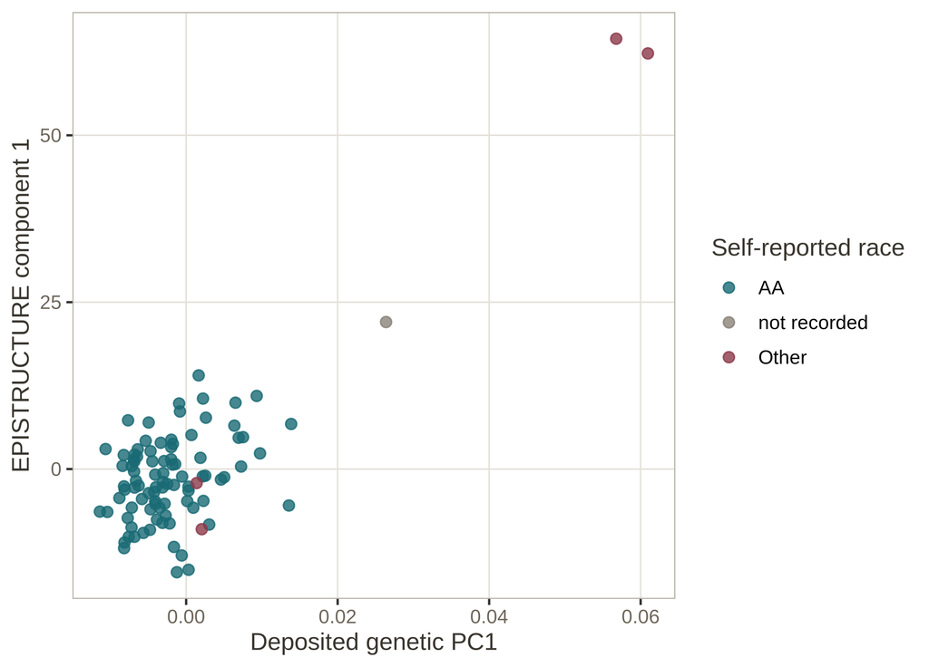

Figure 1: The first EPISTRUCTURE component against the deposited genetic PC1, for the 95 samples with deposited PCs, coloured by self-reported race.

```r
cmp <- data.frame(pc1 = sheet$pc1[has_pcs], EPI1 = epi[has_pcs, 1],
                  race = ifelse(is.na(sheet$race[has_pcs]) | sheet$race[has_pcs] == "",
                                "not recorded", sheet$race[has_pcs]))
ggplot(cmp, aes(pc1, EPI1, colour = race)) +
  geom_point(size = 2.2, alpha = 0.8) +
  scale_colour_manual(values = c(AA = "#1A6B75", Other = "#8C3A4A",
                                 `not recorded` = "#8A8279"),
                      name = "Self-reported race") +
  labs(x = "Deposited genetic PC1", y = "EPISTRUCTURE component 1")
```

EPISTRUCTURE recovers the main ancestry axis reasonably well: its first component correlates with the deposited PC1 at |r| = 0.82, and the three components together explain 68% of PC1’s variance. EPISTRUCTURE’s components explain almost none of PC2 (3%) or PC3 (1%) in this cohort. The table printed by the `epistructure` chunk also shows why it is worth checking what methylation-based components correlate with before using them: with only cell types removed, the first component partly tracks the chip.

**NoteIf you do use EPISTRUCTURE components as covariates**

EPISTRUCTURE doesn’t require removing the reference sites from the association test. A conservative option is to exclude the ones still left after probe filtering, or to note that their association estimates were adjusted for a covariate built partly from their own methylation. Either way, report which option you chose.

**Next:** Batch effects — technical variation from chips, array positions, and plates, and how to detect it before deciding whether to correct.

## References

Barfield, Richard T., Lynn M. Almli, Varun Kilaru, et al. 2014. “Accounting for Population Stratification in DNA Methylation Studies.” *Genetic Epidemiology* 38 (3): 231–41. https://doi.org/10.1002/gepi.21789.

Borrell, Luisa N., Jennifer R. Elhawary, Elena Fuentes-Afflick, et al. 2021. “Race and Genetic Ancestry in Medicine — a Time for Reckoning with Racism.” *New England Journal of Medicine* 384 (5): 474–80. https://doi.org/10.1056/NEJMms2029562.

Bryc, Katarzyna, Eric Y. Durand, J. Michael Macpherson, David Reich, and Joanna L. Mountain. 2015. “The Genetic Ancestry of African Americans, Latinos, and European Americans Across the United States.” *The American Journal of Human Genetics* 96 (1): 37–53. https://doi.org/10.1016/j.ajhg.2014.11.010.

Cattell, Raymond B. 1966. “The Scree Test for the Number of Factors.” *Multivariate Behavioral Research* 1 (2): 245–76. https://doi.org/10.1207/s15327906mbr0102_10.

Chang, Christopher C., Carson C. Chow, Laurent C. A. M. Tellier, Shashaank Vattikuti, Shaun M. Purcell, and James J. Lee. 2015. “Second-Generation PLINK: Rising to the Challenge of Larger and Richer Datasets.” *GigaScience* 4: 7. https://doi.org/10.1186/s13742-015-0047-8.

Jolliffe, Ian T., and Jorge Cadima. 2016. “Principal Component Analysis: A Review and Recent Developments.” *Philosophical Transactions of the Royal Society A: Mathematical, Physical and Engineering Sciences* 374 (2065): 20150202. https://doi.org/10.1098/rsta.2015.0202.

Katrinli, Seyma et al. 2024. “Epigenome-Wide Association Studies Identify Novel DNA Methylation Sites Associated with PTSD: A Meta-Analysis of 23 Military and Civilian Cohorts.” *Genome Medicine* 16: 147. https://doi.org/10.1186/s13073-024-01417-1.

Lewis, Anna C. F., Santiago J. Molina, Paul S. Appelbaum, et al. 2022. “Getting Genetic Ancestry Right for Science and Society.” *Science* 376 (6590): 250–52. https://doi.org/10.1126/science.abm7530.

National Academies of Sciences, Engineering, and Medicine. 2023. *Using Population Descriptors in Genetics and Genomics Research: A New Framework for an Evolving Field*. The National Academies Press. https://doi.org/10.17226/26902.

Novembre, John, Toby Johnson, Katarzyna Bryc, et al. 2008. “Genes Mirror Geography Within Europe.” *Nature* 456 (7218): 98–101. https://doi.org/10.1038/nature07331.

Patterson, Nick, Alkes L. Price, and David Reich. 2006. “Population Structure and Eigenanalysis.” *PLoS Genetics* 2 (12): e190. https://doi.org/10.1371/journal.pgen.0020190.

Price, Alkes L., Nick J. Patterson, Robert M. Plenge, Michael E. Weinblatt, Nancy A. Shadick, and David Reich. 2006. “Principal Components Analysis Corrects for Stratification in Genome-Wide Association Studies.” *Nature Genetics* 38 (8): 904–9. https://doi.org/10.1038/ng1847.

Rahmani, Elior, Liat Shenhav, Regev Schweiger, et al. 2017. “Genome-Wide Methylation Data Mirror Ancestry Information.” *Epigenetics & Chromatin* 10: 1. https://doi.org/10.1186/s13072-016-0108-y.

Rahmani, Elior, Reut Yedidim, Liat Shenhav, et al. 2017. “GLINT: A User-Friendly Toolset for the Analysis of High-Throughput DNA-Methylation Array Data.” *Bioinformatics* 33 (12): 1870–72. https://doi.org/10.1093/bioinformatics/btx059.